# 1. Experiments with reward functions at levels L100 and L200

```python
## Make sure you have deepracer-utils >= 0.9
## Installs and setups: uncomment and run the followings:

# import sys
# !{sys.executable} -m pip install --upgrade deepracer-utils
```

```python
import pandas as pd
import matplotlib.pyplot as plt
from pprint import pprint

from deepracer.tracks import TrackIO, Track
from deepracer.tracks.track_utils import track_breakdown, track_meta
from deepracer.logs import \
    SimulationLogsIO as slio, \
    NewRewardUtils as nr, \
    AnalysisUtils as au, \
    PlottingUtils as pu, \
    ActionBreakdownUtils as abu, \
    DeepRacerLog

# Ignore deprecation warnings we have no power over
import warnings
warnings.filterwarnings('ignore')
```

```python
def time_to_seconds(time_str):
    """
    Convert time in hh:mm.sss format to seconds.
    """
    try:
        minutes, seconds = map(float, time_str.split(":"))
        return minutes * 60 + seconds
    except ValueError:
        return None
```

[figure not shown]

```python
import matplotlib.pyplot as plt
import numpy as np

# Objective Values (Best Time for each Lap)
objective_values_str = ["00:26.862", "00:26.133", "00:25.140", "00:24.219", "00:23.732", "00:23.593", "00:13.072"]
objective_values = [time_to_seconds(time_str) for time_str in objective_values_str]
# print("Converted times to seconds:", objective_values)

# Use-Cases
use_cases = [
   'AUT-L100 | 00:26.862 | Follow-the-Centerline',
   'AUT-L100 | 00:26.133 | Prevent-Zig-Zag',
   'AUT-L100 | 00:25.140 | Stay-within-Borders',
   'AUT-L200 | 00:24.219 | 03-Auckland',
   'AUT-L200 | 00:23.732 | 02-Wellington',
   'AUT-L200 | 00:23.593 | 01-Christchurch',
   'AUT-L300 | 00:12.343 | + Hyperparameters'
]

# Colors for the bars
colors = ['orange', 'orange', 'orange', 'green', 'green', 'darkgreen', 'red']

plt.figure(figsize=(12, 8))

# Create vertical bar chart
bars = plt.barh(use_cases, objective_values, color=colors)

# Annotate the bars with the objective values (Total Costs)
for i, bar in enumerate(bars):
    plt.text(bar.get_width() - (0.01 * bar.get_width()), i, f"⏱️ {objective_values[i]:,}",
             va='center', ha='right', color='white', fontsize=12)
    plt.text(bar.get_width() - (0.99 * bar.get_width()), i, f"{use_cases[i]}",
             va='center', ha='left', color='white', fontsize=12)

# Set axis labels and title
plt.xlabel('Time (HH:MM.sss)')
plt.ylabel('Use-Cases')
# plt.title('Total Cost for Each Use-Case')

# Remove y-ticks as use-cases are already displayed inside the bars
plt.yticks([], [])

# Formatting x-axis labels to display as currency
ax = plt.gca()
ax.xaxis.set_major_formatter(plt.FuncFormatter('{:,.0f} seconds'.format))

plt.legend(bars, use_cases, title='Use-Cases', loc='upper center', bbox_to_anchor=(0.5, 1.15), ncol=3)

plt.tight_layout()
plt.show()
```

## Get the logs

If you're using local training, just point at your model's root folder in the minio bucket. If you're using cloud training, download the model folder to local and point at it.

```python
# Listing information of: the agent and the network, the hyperparameters and some information about the action space.
model_logs_root = 'logs/AUT-L200-ImprovedFunction-Hyperparameters-training_job'
log = DeepRacerLog(model_logs_root)

# load logs into a dataframe
log.load()

try:
    pprint(log.agent_and_network())
    print("-------------")
    pprint(log.hyperparameters())
    print("-------------")
    pprint(log.action_space())
except Exception:
    print("Robomaker logs not available")

df = log.dataframe()

## DEBUG
# df.head()
```

```
{'network': 'DEEP_CONVOLUTIONAL_NETWORK_SHALLOW',
 'sensor_list': ['FRONT_FACING_CAMERA'],
 'simapp_version': '5.0',
 'world': 'reInvent2019_trac...'}
-------------
{'batch_size': 256,
 'beta_entropy': 0.005,
 'discount_factor': 0.9999,
 'e_greedy_value': 1.0,
 'epsilon_steps': 10000,
 'exploration_type': 'categorical',
 'loss_type': 'huber',
 'lr': 0.0001,
 'num_episodes_between_training': 15,
 'num_epochs': 10,
 'stack_size': 1,
 'term_cond_avg_score': 100000.0,
 'term_cond_max_episodes': 100000}
-------------
{'speed': {'high': 3.5, 'low': 0.5},
 'steering_angle': {'high': 30.0, 'low': -30.0}}
```

# 2. Training Analysis for DeepRacer

**Training Analysis for DeepRacer Notebook**

This notebook has been built based on the `DeepRacer Log Analysis.ipynb` provided by the AWS DeepRacer Team. It has been reorganised and expanded to provide new views on the training data and try hacking around to get the insights that suit our needs.

- Credits: We would like to thank [the AWS DeepRacer Community](http://join.deepracing.io) and [codelikeamother blog](https://codelikeamother.uk) for code samples and experiences with AWS DeepRacer.
- Permissions: Depending on where you are downloading the data from, we will need some permissions: access to CloudWatch log streams and S3 bucket to reach the log files.

## Load waypoints for the track you want to run analysis on

The track waypoint files represent the coordinates of characteristic points of the track - the center line, inside border and outside border. Their main purpose is to visualise the Smile Speedway track (reInvent2019_track_ccw).

```python
# Tracks Available:
tu = TrackIO()

for track in tu.get_tracks():
    print("{}".format(track, track_meta.get(track[:-4])))
    # print("{} - {}".format(track, track_meta.get(track[:-4], "I don't know")))
```

```
reInvent2019_track_ccw.npy
```

```
Loaded 79 waypoints
```

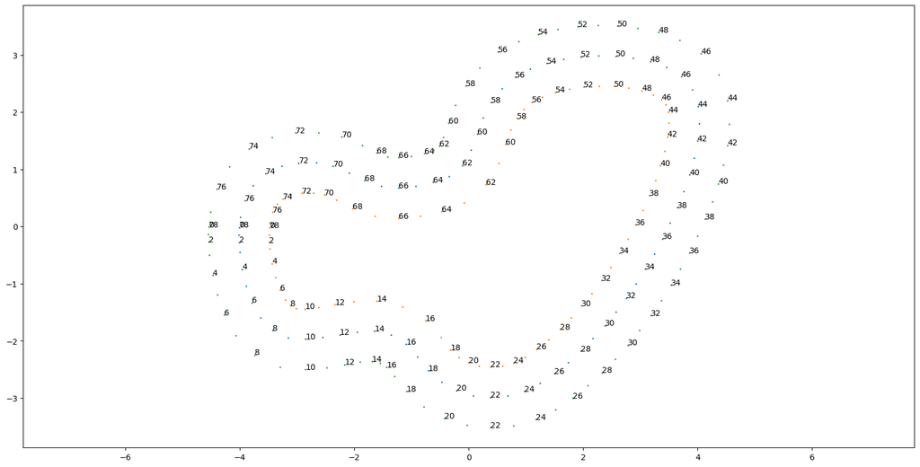

```python
## Load the track:
# track_name = log.agent_and_network()["world"]
track_name = "reInvent2019_track_ccw"

track: Track = tu.load_track(track_name)

pu.plot_trackpoints(track, annotate_every_nth = 2)
```

## Data in tables

```python
# Completion rate per iteration
simulation_agg = au.simulation_agg(df)

# Stats for complete laps
complete_ones = simulation_agg[simulation_agg['progress']==100]

# View ten best rewarded episodes in the training
# simulation_agg.nlargest(10, 'new_reward')

# View five fastest complete laps
complete_ones.nsmallest(5, 'time')
```

```
new reward not found, using reward as its values
```

|  | iteration | episode | steps | start_at | progress | time | dist | new_reward | speed | reward | time_if_complete | reward_if_complete | quintile | complete |
| --- | --- | --- | --- | --- | --- | --- | --- | --- | --- | --- | --- | --- | --- | --- |
| 440 | 30 | 440 | 197 | 1 | 100.0 | 13.072 | 23.046555 | 90.7706 | 2.064670 | 90.7706 | 13.072 | 90.7706 | 4th | 1 |
| 512 | 35 | 512 | 204 | 48 | 100.0 | 13.534 | 22.002249 | 86.8796 | 1.874804 | 86.8796 | 13.534 | 86.8796 | 5th | 1 |
| 495 | 34 | 495 | 208 | 59 | 100.0 | 13.794 | 22.199140 | 87.2344 | 1.896394 | 87.2344 | 13.794 | 87.2344 | 5th | 1 |
| 460 | 31 | 460 | 211 | 1 | 100.0 | 14.010 | 22.370281 | 88.8287 | 1.891422 | 88.8287 | 14.010 | 88.8287 | 5th | 1 |
| 555 | 38 | 555 | 212 | 59 | 100.0 | 14.068 | 22.287072 | 89.3394 | 1.824434 | 89.3394 | 14.068 | 89.3394 | 5th | 1 |

```python
# View five best rewarded completed laps
# complete_ones.nlargest(5, 'reward')

# View five best rewarded in completed laps (according to new_reward if you are using it)
# complete_ones.nlargest(5, 'new_reward')

# View five most progressed episodes
# simulation_agg.nlargest(5, 'progress')

# View information for a couple first episodes
# simulation_agg.head()
```

## Analyze the reward distribution for your reward function

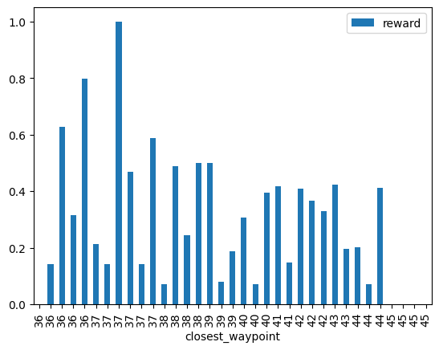

```python
## Identify potential reward-granting issues using this histogram of actions per nearest waypoint
episode = df[df['episode']==9]

if episode.empty:
    print("You probably don't have episode with this number, try a lower one.")
else:
    episode.plot.bar(x='closest_waypoint', y='reward')
    # episode[:-1].plot.bar(x='closest_waypoint', y='reward')
```

### Path taken for top reward iterations

The plot_selected_laps graphs give a chance to look deeper into our car's behaviour on track.

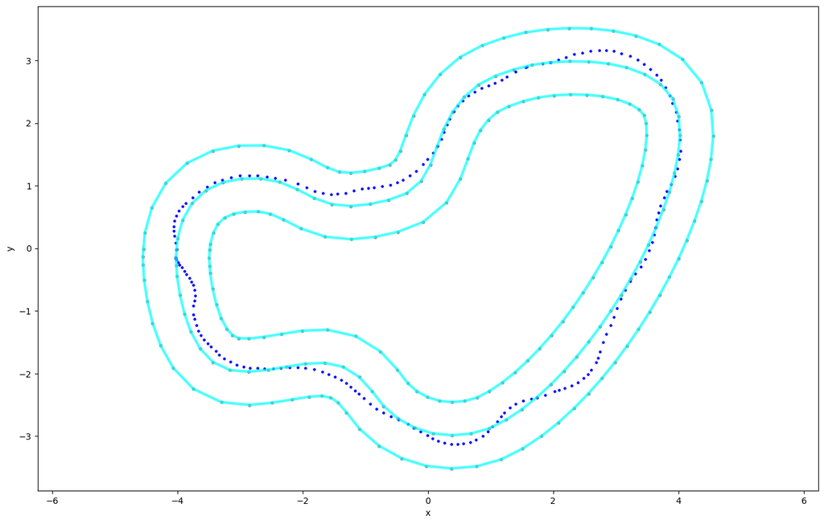

```python
# highest reward for complete laps:
# episodes_to_plot = complete_ones.nlargest(2,'reward')

# highest progress from all episodes:
episodes_to_plot = simulation_agg.nlargest(1,'progress')

pu.plot_selected_laps(episodes_to_plot, df, track)
```

### Plot a Heatmap of Rewards for current training.

The brighter the colour, the higher the reward granted in the given coordinates.

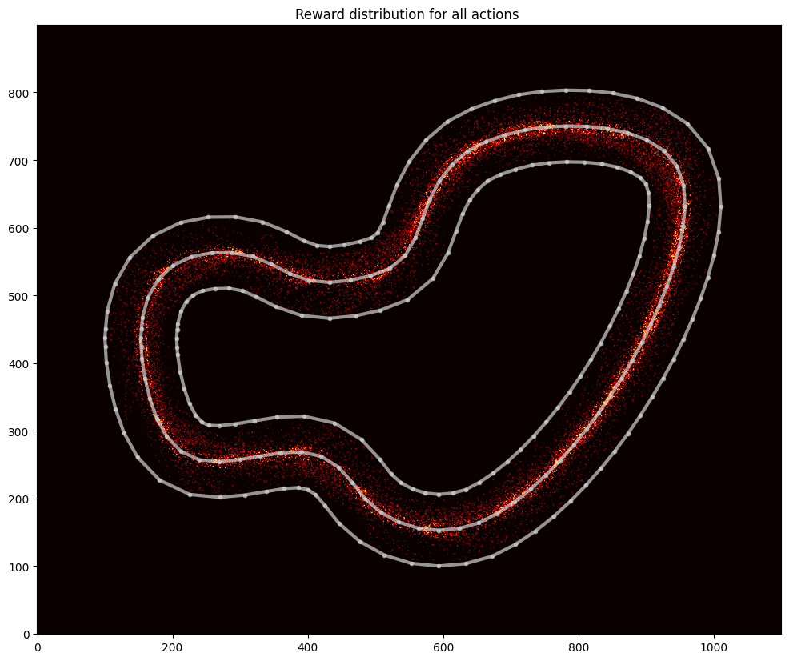

```python
## can specify a different column in the value_field parameter
pu.plot_track(df, track)
```

```python
## Plot a particular iteration
## This is same as the heatmap above, but just for a single iteration.

# #If you'd like some other colour criterion, you can add
# #a value_field parameter and specify a different column
# iteration_id = 3

# pu.plot_track(df[df['iteration'] == iteration_id], track)

## Path taken in a particular episode
# episode_id = 12

# pu.plot_selected_laps([episode_id], df, track)
```

### Path taken in a particular iteration

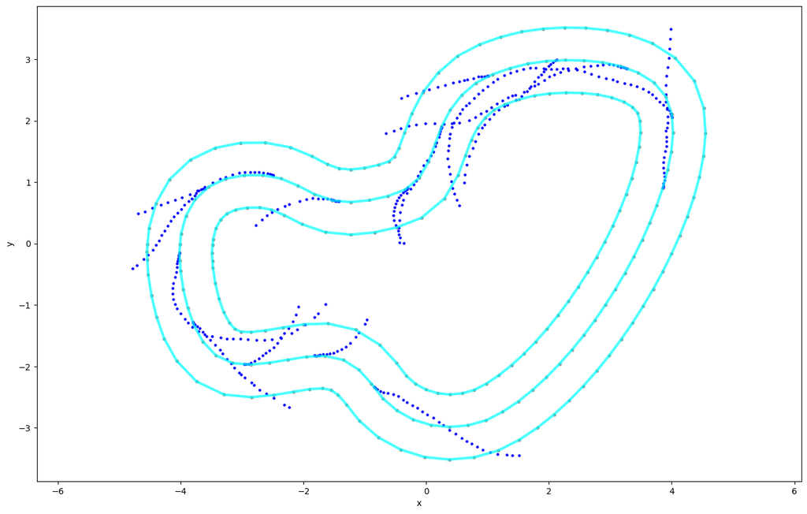

```python
iteration_id = 11

pu.plot_selected_laps([iteration_id], df, track, section_to_plot = 'iteration')
```

# 3. Calculation of the optimal Racing Line

Inspired by the paper [Reinforcement Learning Using Neural Networks, with Applications to Motor Control](https://www.remi-coulom.fr/Publications/Thesis.pdf) , which is referenced by a number of machine learning articles, to calculate a race line around a simple race track.

```python
import glob
import numpy as np
from shapely.geometry import Point, Polygon
from shapely.geometry.polygon import LinearRing, LineString
import pandas as pd
import matplotlib.pyplot as plt
import os.path
```

## Load the track to analyze

```python
# # Conveniently list available tracks to analyze
# available_track_files = glob.glob("./tracks/**.npy")
# available_track_names = list(map(lambda x: os.path.basename(x).split('.npy')[0], available_track_files))
# available_track_names

# The Smile Speedway track to analyze
TRACK_NAME = 'reInvent2019_track_ccw'

# Load the center, inner, outer waypoints
waypoints = np.load("./tracks/%s.npy" % TRACK_NAME)

# Convert to Shapely objects
center_line = waypoints[:,0:2]
inner_border = waypoints[:,2:4]
outer_border = waypoints[:,4:6]
l_center_line = LineString(center_line)
l_inner_border = LineString(inner_border)
l_outer_border = LineString(outer_border)
flipped = np.flipud(list(l_inner_border.coords))
line_tuple = (list(l_outer_border.coords), flipped)
road_poly = Polygon(np.vstack(line_tuple))
print("Is loop/ring? ", l_center_line.is_ring)
road_poly
```

```
Is loop/ring?  True
```

# Display the original track waypoints

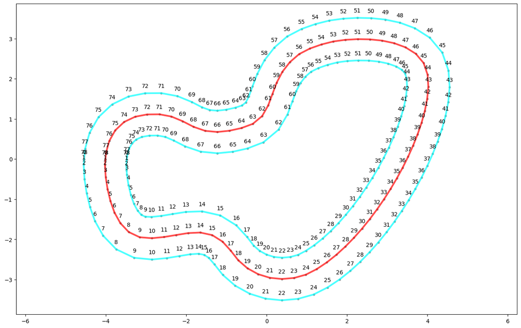

```python
# Plot coordinates for a LineString
def plot_coords(ax, ob):
    x, y = ob.xy
    ax.plot(x, y, '.', color='#999999', zorder=1)
    for i, (xi, yi) in enumerate(zip(x, y)):
            ax.annotate(str(i), (xi, yi), textcoords="offset points", xytext=(0, 10), ha='center')

def plot_bounds(ax, ob):
    x, y = zip(*list((p.x, p.y) for p in ob.boundary))
    ax.plot(x, y, '.', color='#000000', zorder=1)

# Plot a line for a LineString
def plot_line(ax, ob, color='cyan'):
    x, y = ob.xy
    ax.plot(x, y, color, alpha=0.7, linewidth=3, solid_capstyle='round', zorder=2)

# Print the border lines for the race track
def print_border(ax, waypoints, inner_border_waypoints, outer_border_waypoints):
    line = LineString(waypoints)
    plot_coords(ax, line)
    plot_line(ax, line, color='red')

    line = LineString(inner_border_waypoints)
    plot_coords(ax, line)
    plot_line(ax, line)

    line = LineString(outer_border_waypoints)
    plot_coords(ax, line)
    plot_line(ax, line)

fig = plt.figure(1, figsize=(16, 10))
ax = fig.add_subplot(111, facecolor='white')
plt.axis('equal')
print_border(ax, center_line, inner_border, outer_border)
```

```python
# From https://github.com/e-koch/ewky_scripts/blob/master/curvature.py
# The MIT License (MIT)
# Copyright (c) 2014 Eric Koch

def menger_curvature(pt1, pt2, pt3, atol=1e-3):

    vec21 = np.array([pt1[0]-pt2[0], pt1[1]-pt2[1]])
    vec23 = np.array([pt3[0]-pt2[0], pt3[1]-pt2[1]])

    norm21 = np.linalg.norm(vec21)
    norm23 = np.linalg.norm(vec23)

    theta = np.arccos(np.dot(vec21, vec23)/(norm21*norm23))
    if np.isclose(theta-np.pi, 0.0, atol=atol):
        theta = 0.0

    dist13 = np.linalg.norm(vec21-vec23)

    return 2*np.sin(theta) / dist13
```

```python
import copy
from shapely.geometry import Point, Polygon
from shapely.geometry.polygon import LinearRing, LineString

# Number of times to iterate each new race line point
# keep this at 3-8 for best balance of performance and desired result
XI_ITERATIONS=4

# Number of times to scan the entire race track to iterate
# 500 will get a good start, 1500 will be closer to optimal result
LINE_ITERATIONS=1000

def improve_race_line(old_line, inner_border, outer_border):
    '''Use gradient descent, inspired by K1999, to find the racing line'''
    # start with the center line
    new_line = copy.deepcopy(old_line)
    ls_inner_border = Polygon(inner_border)
    ls_outer_border = Polygon(outer_border)
    for i in range(0,len(new_line)):
        xi = new_line[i]
        npoints = len(new_line)
        prevprev = (i - 2 + npoints) % npoints
        prev = (i - 1 + npoints) % npoints
        nexxt = (i + 1 + npoints) % npoints
        nexxtnexxt = (i + 2 + npoints) % npoints
        #print("%d: %d %d %d %d %d" % (npoints, prevprev, prev, i, nexxt, nexxtnexxt))
        ci = menger_curvature(new_line[prev], xi, new_line[nexxt])
        c1 = menger_curvature(new_line[prevprev], new_line[prev], xi)
        c2 = menger_curvature(xi, new_line[nexxt], new_line[nexxtnexxt])
        target_ci = (c1 + c2) / 2
        #print("i %d ci %f target_ci %f c1 %f c2 %f" % (i, ci, target_ci, c1, c2))

        # Calculate prospective new track position, start at half-way (curvature zero)
        xi_bound1 = copy.deepcopy(xi)
        xi_bound2 = ((new_line[nexxt][0] + new_line[prev][0]) / 2.0, (new_line[nexxt][1] + new_line[prev][1]) / 2.0)
        p_xi = copy.deepcopy(xi)
        for j in range(0,XI_ITERATIONS):
            p_ci = menger_curvature(new_line[prev], p_xi, new_line[nexxt])
            #print("i: {} iter {} p_ci {} p_xi {} b1 {} b2 {}".format(i,j,p_ci,p_xi,xi_bound1, xi_bound2))
            if np.isclose(p_ci, target_ci):
                break
            if p_ci < target_ci:
                # too flat, shrinking track too much
                xi_bound2 = copy.deepcopy(p_xi)
                new_p_xi = ((xi_bound1[0] + p_xi[0]) / 2.0, (xi_bound1[1] + p_xi[1]) / 2.0)
                if Point(new_p_xi).within(ls_inner_border) or not Point(new_p_xi).within(ls_outer_border):
                    xi_bound1 = copy.deepcopy(new_p_xi)
                else:
                    p_xi = new_p_xi
            else:
                # too curved, flatten it out
                xi_bound1 = copy.deepcopy(p_xi)
                new_p_xi = ((xi_bound2[0] + p_xi[0]) / 2.0, (xi_bound2[1] + p_xi[1]) / 2.0)

                # If iteration pushes the point beyond the border of the track,
                # just abandon the refinement at this point.  As adjacent
                # points are adjusted within the track the point should gradually
                # make its way to a new position.  A better way would be to use
                # a projection of the point on the border as the new bound.  Later.
                if Point(new_p_xi).within(ls_inner_border) or not Point(new_p_xi).within(ls_outer_border):
                    xi_bound2 = copy.deepcopy(new_p_xi)
                else:
                    p_xi = new_p_xi
        new_xi = p_xi
        # New point which has mid-curvature of prev and next points but may be outside of track
        #print((new_line[i], new_xi))
        new_line[i] = new_xi

    return new_line
```

## Calculate the race line!

```python
print(len(center_line))
# start along centerline of track
race_line = copy.deepcopy(center_line[:-1])  # Use this for centerline being outer bound
for i in range(LINE_ITERATIONS):
    race_line = improve_race_line(race_line, inner_border, outer_border)
    # if i % 20 == 0: print("Iteration %d" % i)
```

```
79
```

```
These should be the same:  ((79, 2), (79, 2))
Original centerline length: 23.09
New race line length: 19.25
```

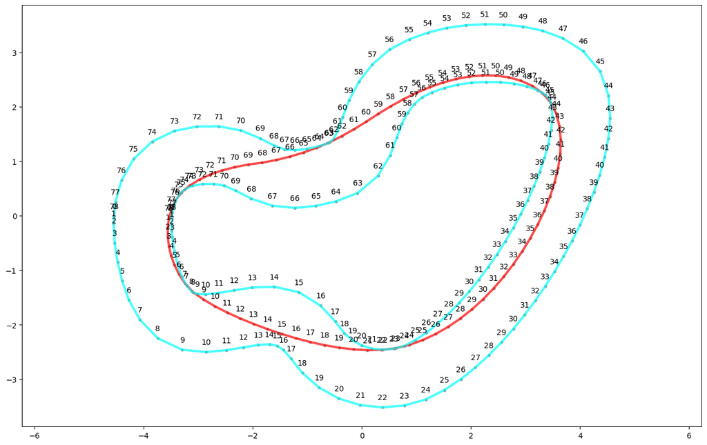

```python
# need to put duplicate point race_line[0] at race_line[-1] to make a closed loops
loop_race_line = np.append(race_line, [race_line[0]], axis=0)

# These should be the same
print("These should be the same: ", (center_line.shape, loop_race_line.shape))
print("Original centerline length: %0.2f" % l_center_line.length)
print("New race line length: %0.2f" % LineString(loop_race_line).length)

fig = plt.figure(1, figsize=(16, 10))
ax = fig.add_subplot(111, facecolor='white')
plt.axis('equal')
print_border(ax, loop_race_line, inner_border, outer_border)
```

## Save the raceline as:

1. Binary numpy array for loading from a file
2. Text numpy array for pasting directly into a reward function

```python
from datetime import datetime

now = datetime.now()
# prefix = './racelines/%s-%d-%d-%s' % (TRACK_NAME, LINE_ITERATIONS, XI_ITERATIONS, now.strftime('%Y-%m-%d-%H%M%S'))
prefix = 'AUT-Race-Smile-Speedway-Track'
py_fname = prefix + '.py'
npy_fname = prefix + '.npy'
with open(py_fname, "w") as file:
    print("Writing python code to %s" % py_fname)
    file.write(np.array_repr(loop_race_line))

print("Writing numpy binary to %s" % npy_fname)
np.save(npy_fname, loop_race_line)
```

```
Writing python code to AUT-Race-Smile-Speedway-Track.py
Writing numpy binary to AUT-Race-Smile-Speedway-Track.npy
```

# Load and visualize a stored track file

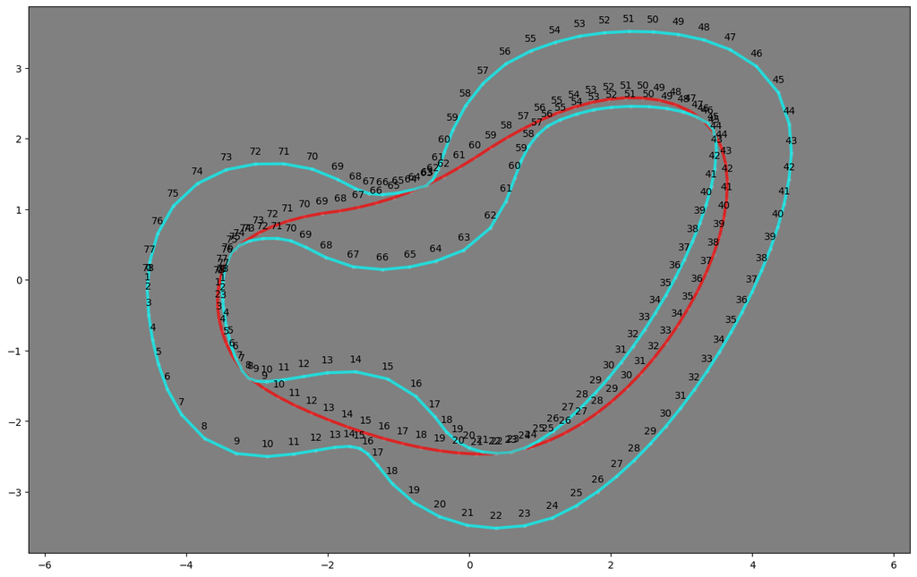

```python
from numpy import array

fname = './racelines/AUT-Race-Smile-Speedway-Track.py'
with open(fname, "r") as file:
    deserialized = eval(file.read())
deserialized
fig = plt.figure(1, figsize=(16, 10))
ax = fig.add_subplot(111, facecolor='gray')
plt.axis('equal')
print_border(ax, deserialized, inner_border, outer_border)
```